# An Introduction to Statistical Learning (2013)

Solutions to Exercises

by Brian Hassett

# Chapter 6 Conceptual Exercises

## Exercise 1

*We perform best subset, forward stepwise, and backward stepwise selection on a single data set. For each approach, we obtain $p+1$ models, containing $0, 1, 2, \ldots, p$ predictors. Explain your answers:*

1. *Which of the three models with $k$ predictors has the smallest training RSS?*
2. *Which of the three models with $k$ predictors has the smallest test RSS?*
3. *True or False:*
1. *The predictors in the $k$-variable model identified by forward stepwise are a subset of the predictors in the $(k+1)$-variable model identified by forward stepwise selection.*
2. *The predictors in the $k$-variable model identified by backward stepwise are a subset of the predictors in the $(k+1)$-variable model identified by backward stepwise selection.*
3. *The predictors in the $k$-variable model identified by backward stepwise are a subset of the predictors in the $(k+1)$-variable model identified by forward stepwise selection.*
4. *The predictors in the $k$-variable model identified by forward stepwise are a subset of the predictors in the $(k+1)$-variable model identified by backward stepwise selection.*
5. *The predictors in the $k$-variable model identified by best subset are a subset of the predictors in the $(k+1)$-variable model identified by best subset selection.*

### (a)

Best subset selection will have the lowest training RSS. Forward stepwise selection and backward stepwise selection are not guaranteed to find the combination of predictors which gives the lowest RSS, while best subset selection always will.

### (b)

Not possible to say. Even though the best subset selection method will provide a model which performs best on the training data, the other methods may provide models which perform best on the test data. If for example the best subset model has overfit the training data, then one of the other models may happen to perform better on the test data.

### (c)

#### (i)

**True**: Forward stepwise selection does not drop previously chosen predictors, but instead adds the next most informative variable. Thus the predictors in the $k$-variable model identified by forward stepwise selection are a subset of the predictors in the ($k+1$)-variable model identified by forward stepwise selection.

#### (ii)

**True**: Backward stepwise selection drops *one variable at a time*, meaning that predictor in the $k$-variable model identified by backward stepwise selection are a subset of the predictors in the ($k+1$)-variable model identified by backward stepwise selection.

#### (iii)

**False**: There is no link between the models found by forward stepwise selection and backward stepwise selection.

#### (iv)

**False**: There is no link between the models found by forward stepwise selection and backward stepwise selection.

#### (v)

**False**: The model with ($k+1$) predictors is obtained by selecting among all possible models with ($k+1$) predictors, and so does not necessarily contain all the predictors selected for the $k$-variable model.

## Exercise 2

*For parts (a) through (c), indicate which of i. through iv. is correct. Justify your answer.*

1. *The lasso, relative to least squares, is:*
1. *More flexible and hence will give improved prediction accuracy when its increase in bias is less than its decrease in variance.*
2. *More flexible and hence will give improved prediction accuracy when its increase in variance is less than its decrease in bias.*
3. *Less flexible and hence will give improved prediction accuracy when its increase in bias is less than its decrease in variance.*
4. *Less flexible and hence will give improved prediction accuracy when its increase in variance is less than its decrease in bias.*
2. *Repeat (a) for ridge regression relative to least squares.*
3. *Repeat (a) for non-linear methods relative to least squares.*

### (a)

The correct answer is **(iii)**:  
The **lasso** is less flexible and hence will give improved prediction accuracy when its increase in bias is less than its decrease in variance.

### (b)

The correct answer is **(iii)**:  
**Ridge regression** is less flexible and hence will give improved prediction accuracy when its increase in bias is less than its decrease in variance.

### (c)

The correct answer is **(ii)**:  
**Non-linear methods** are more flexible and hence will give improved prediction accuracy when their increase in variance is less than their decrease in bias.

## Exercise 3

*Suppose we estimate the regression coefficients in a linear regression model by minimizing*

$$\sum_{i=1}^{n}\left(y_{i}-\beta_{0}-\sum_{j=1}^{p} \beta_{j} x_{i j}\right)^{2} \text{subject to } \sum_{j=1}^{p} |\beta_{j}| \le s$$

*for a particular value of $s$. For parts (a) through (e), indicate which of i. through v. is correct. Justify your answer.*

1. *As we increase $s$ from $0$, the training RSS will:*
1. *Increase initially, and then eventually start decreasing in an inverted U shape.*
2. *Decrease initially, and then eventually start increasing in a U shape.*
3. *Steadily increase.*
4. *Steadily decrease.*
5. *Remain constant.*
2. *Repeat (a) for test RSS.*
3. *Repeat (a) for variance.*
4. *Repeat (a) for (squared) bias.*
5. *Repeat (a) for the irreducible error.*

### (a)

**Training RSS**  
The correct answer is **(iv)**:  
Steadily decrease. As we increase $s$ from $0$, we are restricting the $\beta_{j}$ coefficients less and less (the coefficients will increase to their least squares estimates as $s \rightarrow \infty$). The model becomes more and more flexible which leads to a steady decrease in the training RSS.

### (b)

**Test RSS**  
The correct answer is **(ii)**:  
Decrease initially, and then eventually start increasing in a U shape. As we increase $s$ from $0$, we are restricting the $\beta_{j}$ coefficients less and less (the coefficients will increase to their least squares estimates as $s \rightarrow \infty$). The model becomes more and more flexible which leads to an initial decrease in the test RSS, before it increases again in a U shape. The increase is due to the more flexible model overfitting the training data.

### (c)

**Variance**  
The correct answer is **(iii)**:  
Steadily increase. As we increase $s$ from $0$, we are restricting the $\beta_{j}$ coefficients less and less (the coefficients will increase to their least squares estimates as $s \rightarrow \infty$). The model becomes more and more flexible which leads to a steady increase in variance.

### (d)

**Squared Bias**  
The correct answer is **(iv)**:  
Steadily decrease. As we increase $s$ from $0$, we are restricting the $\beta_{j}$ coefficients less and less (the coefficients will increase to their least squares estimates as $s \rightarrow \infty$). The model becomes more and more flexible which leads to a steady decrease in bias.

### (e)

**Irreducible Error**  
The correct answer is **(v)**:  
Remain constant. By definition, the irreducible error is independent of the model, and consequently independent of the value of $s$.

## Exercise 4

*Suppose we estimate the regression coefficients in a linear regression model by minimizing*

$$\sum_{i=1}^{n}\left(y_{i}-\beta_{0}-\sum_{j=1}^{p} \beta_{j} x_{i j}\right)^{2} + \lambda \sum_{j=1}^{p}\beta_{j}^2$$

*for a particular value of $\lambda$. For parts (a) through (e), indicate which of i. through v. is correct. Justify your answer.*

1. *As we increase $\lambda$ from $0$, the training RSS will:*
1. *Increase initially, and then eventually start decreasing in an inverted U shape.*
2. *Decrease initially, and then eventually start increasing in a U shape.*
3. *Steadily increase.*
4. *Steadily decrease.*
5. *Remain constant.*
2. *Repeat (a) for test RSS.*
3. *Repeat (a) for variance.*
4. *Repeat (a) for (squared) bias.*
5. *Repeat (a) for the irreducible error.*

### (a)

**Training RSS**  
The correct answer is **(iii)**:  
Steadily increase. As we increase $\lambda$ from $0$, we are restricting the $\beta_{j}$ coefficients more and more (the coefficients will deviate from the least squares estimates). The model becomes less and less flexible which leads to a steady increase in training RSS.

### (b)

**Test RSS**  
The correct answer is **(ii)**:  
Decrease initially, and then eventually start increasing in a U shape. As we increase $\lambda$ from $0$, we are restricting the $\beta_{j}$ coefficients more and more (the coefficients will deviate from the least squares estimates). The model becomes less and less flexible which leads to an initial decrease in the test RSS, before it increases again in a U shape.

### (c)

**Variance**  
The correct answer is **(iv)**:  
Steadily decrease. As we increase $\lambda$ from $0$, we are restricting the $\beta_{j}$ coefficients more and more (the coefficients will deviate from the least squares estimates). The model becomes less and less flexible which leads to a steady decrease in variance.

### (d)

**Squared Bias**  
The correct answer is **(iii)**:  
Steadily increase. As we increase $\lambda$ from $0$, we are restricting the $\beta_{j}$ coefficients more and more (the coefficients will deviate from the least squares estimates). The model becomes less and less flexible which leads to a steady increase in bias.

### (e)

**Irreducible Error**  
The correct answer is **(v)**:  
Remain constant. By definition, the irreducible error is independent of the model, and consequently independent of the value of $\lambda$.

## Exercise 5

*It is well-known that ridge regression tends to give similar coefficient values to correlated variables, whereas the lasso may give quite different coefficient values to correlated variables. We will now explore this property in a very simple setting.*

*Suppose that $n = 2$, $p = 2$, $x_{11} = x_{12}$ , $x_{21} = x_{22}$ . Furthermore, suppose that $y_1 + y_2 = 0$ and $x_{11} + x_{21} = 0$ and $x_{12} + x_{22} = 0$, so that the estimate for the intercept in a least squares, ridge regression, or lasso model is zero: $\hat{\beta_0} = 0$.*

1. *Write out the ridge regression optimization problem in this setting.*
2. *Argue that in this setting, the ridge coefficient estimates satisfy $\hat{\beta_1} = \hat{\beta_2}$.*
3. *Write out the lasso optimization problem in this setting.*
4. *Argue that in this setting, the lasso coefficients $\hat{\beta_1}$ and $\hat{\beta_2}$ are not unique-in other words, there are many possible solutions to the optimization problem in (c). Describe these solutions.*

### (a)

The ridge regression coefficients, $\hat{\beta}^R$, minimize the quantity
$$\sum_{i=1}^{n}\left(y_{i}-\beta_{0}-\sum_{j=1}^{p} \beta_{j} x_{i j}\right)^{2}+\lambda \sum_{j=1}^{p} \beta_{j}^{2}=\mathrm{RSS}+\lambda \sum_{j=1}^{p} \beta_{j}^{2} \hspace{2cm} (6.5)$$
We have
$$n=2,~ p=2,~ x_{11}=x_{12},~ x_{21}=x_{22},$$
$$y_{1}+y_{2}=0,~ x_{11}+x_{21}=0,~ x_{12}+x_{22}=0,$$
$$\beta_{0}=0.$$
This allows us to write the ridge regression optimization problem in this setting as:
$$\left(y_{1}- (0) - (\beta_{1} x_{1 1} + \beta_{2} x_{1 2})\right)^{2} + \left(y_{2}- (0) - (\beta_{1} x_{2 1} + \beta_{2} x_{2 2})\right)^{2}
+ \lambda (\beta_{1}^{2} + \beta_{2}^{2})$$

Additionally, we can use the following shorthand notation:
$$x_1 = x_{1 1} = x_{1 2},~ x_2 = x_{2 1} = x_{2 2}.$$
This gives us
$$\left(y_{1} - (\beta_{1} x_{1} + \beta_{2} x_{1})\right)^{2} + \left(y_{2} - (\beta_{1} x_{2} + \beta_{2} x_{2})\right)^{2}
+ \lambda (\beta_{1}^{2} + \beta_{2}^{2}).$$

### (b)

From (a), we seek to minimize
$$\left(y_{1} - (\beta_{1} x_{1} + \beta_{2} x_{1})\right)^{2} + \left(y_{2} - (\beta_{1} x_{2} + \beta_{2} x_{2})\right)^{2}
+ \lambda (\beta_{1}^{2} + \beta_{2}^{2})$$
To simplify further, we can use the following shorthand
$$x=x_{1}=-x_{2},~ y=y_{1}=-y_{2}.$$
This gives us
$$\left(y - (\beta_{1} x + \beta_{2} x)\right)^{2} + \left((-y) - (\beta_{1} (-x) + \beta_{2} (-x))\right)^{2}
+ \lambda (\beta_{1}^{2} + \beta_{2}^{2})$$
$$\left(y - (\beta_{1} x + \beta_{2} x)\right)^{2} + \left(-y + (\beta_{1}x + \beta_{2}x)\right)^{2}
+ \lambda (\beta_{1}^{2} + \beta_{2}^{2})$$
$$\left(y^2 - 2yx(\beta_{1} + \beta_{2}) + (x(\beta_{1} + \beta_{2}))^2\right) + \left(y^2 - 2yx(\beta_{1} + \beta_{2}) + (x(\beta_{1} + \beta_{2}))^2\right)
+ \lambda (\beta_{1}^{2} + \beta_{2}^{2})$$
$$2y^2 - 4yx(\beta_{1} + \beta_{2}) + 2(x(\beta_{1} + \beta_{2}))^2
+ \lambda (\beta_{1}^{2} + \beta_{2}^{2})$$
$$2y^2 - 4yx(\beta_{1} + \beta_{2}) + 2(x^2(\beta^2_{1} + 2\beta_{1}\beta_{2} + \beta^2_{2}))
+ \lambda (\beta_{1}^{2} + \beta_{2}^{2})$$
$$2y^2 - 4yx\beta_{1} - 4yx\beta_{2} + 2x^2\beta^2_{1} + 4x^2\beta_{1}\beta_{2} + 2x^2\beta^2_{2}
+ \lambda \beta_{1}^{2} + \lambda \beta_{2}^{2}$$
To find $\hat{\beta}_{1}$, take the derivative w.r.t. $\beta_{1}$ and set it equal to zero:
$$\frac{\partial }{\partial \beta_{1}} \left(2y^2 - 4yx\beta_{1} - 4yx\beta_{2} + 2x^2\beta^2_{1} + 4x^2\beta_{1}\beta_{2} + 2x^2\beta^2_{2}
+ \lambda \beta_{1}^{2} + \lambda \beta_{2}^{2} \right) = 0$$

$$\left((0) - 4yx - (0) + 4x^2\beta_{1} + 4x^2\beta_{2} + (0)
+ 2\lambda \beta_{1} + (0) \right) = 0$$

$$-4yx + 4x^2\beta_{1} + 4x^2\beta_{2}
+ 2\lambda \beta_{1} = 0$$

$$\beta_{1}(4x^2 + 2\lambda) = 4yx -4x^2\beta_{2}$$
$$\hat{\beta}_{1} = \frac{2yx -2x^2\beta_{2}}{2x^2 + \lambda}$$

To find $\hat{\beta}_{2}$, take derivative w.r.t. $\beta_{2}$ and set it equal to zero:
$$\frac{\partial }{\partial \beta_{2}} \left(2y^2 - 4yx\beta_{1} - 4yx\beta_{2} + 2x^2\beta^2_{1} + 4x^2\beta_{1}\beta_{2} + 2x^2\beta^2_{2}
+ \lambda \beta_{1}^{2} + \lambda \beta_{2}^{2} \right) = 0$$
$$\left((0) - (0) - 4yx + (0) + 4x^2\beta_{1} + 4x^2\beta_{2}
+ (0) + \lambda 2\beta_{2} \right) = 0$$

$$-4yx + 4x^2\beta_{1} + 4x^2\beta_{2} + 2\lambda \beta_{2} = 0$$

$$\beta_{2}(2x^2 + \lambda) = 2yx - 2x^2\beta_{1}$$
$$\hat{\beta}_{2} = \frac{2yx - 2x^2\beta_{1}}{2x^2 + \lambda}$$

Set $\hat{\beta}_{1} = \hat{\beta}_{2}$
$$\frac{2yx -2x^2\beta_{2}}{2x^2 + \lambda} = \frac{2yx - 2x^2\beta_{1}}{2x^2 + \lambda}$$
After some cancelling and rearranging we see that $\hat{\beta_1}= \hat{\beta_2}$ in this setting. $\hspace{1cm} \square$

### (c)

The lasso coefficients, $\beta^L_{\lambda}$, minimize the quantity
$$\sum_{i=1}^{n}\left(y_{i}-\beta_{0}-\sum_{j=1}^{p} \beta_{j} x_{i j}\right)^{2}+\lambda \sum_{j=1}^{p} |\beta_{j}| = \mathrm{RSS}+\lambda \sum_{j=1}^{p} |\beta_{j}| \hspace{2cm} (6.7)$$

We have
$$n=2,~ p=2,~ x_{11}=x_{12},~ x_{21}=x_{22},$$
$$y_{1}+y_{2}=0,~ x_{11}+x_{21}=0,~ x_{12}+x_{22}=0,$$
$$\beta_{0}=0.$$
This allows us to write the lasso optimization problem in this setting as:
$$\left(y_{1}- (0) - (\beta_{1} x_{1 1} + \beta_{2} x_{1 2})\right)^{2} + \left(y_{2}- (0) - (\beta_{1} x_{2 1} + \beta_{2} x_{2 2})\right)^{2}
+ \lambda (|\beta_{1}| + |\beta_{2}|)$$
Additionally, we can use the following shorthand notation:
$$x_1 = x_{1 1} = x_{1 2},~ x_2 = x_{2 1} = x_{2 2}.$$
This gives us
$$\left(y_{1} - (\beta_{1} x_{1} + \beta_{2} x_{1})\right)^{2} + \left(y_{2} - (\beta_{1} x_{2} + \beta_{2} x_{2})\right)^{2}
+ \lambda (|\beta_{1}| + |\beta_{2}|)$$

## Exercise 6

*We will now explore (6.12) and (6.13) further.*

1. *Consider (6.12) with $p = 1$. For some choice of $y_1$ and $\lambda > 0$, plot (6.12) as a function of $\beta_1$. Your plot should confirm that (6.12) is solved by (6.14).*
2. *Consider (6.13) with $p = 1$. For some choice of $y_1$ and $\lambda > 0$, plot (6.13) as a function of $\beta_1$. Your plot should confirm that (6.13) is solved by (6.15).*

### (a)

In this part we are exploring (6.12) and (6.14):
$$\sum_{j=1}^{p} (y_j - \beta_j)^2 + \lambda \sum_{j=1}^{p} \beta_{j}^2 \hspace{2cm} (6.12)$$
$$\hat{\beta}_j^R = y_j/(1 + \lambda) \hspace{2cm} (6.14)$$

Let $y_1 = 2.5$ and $\lambda = 0.5$. Below is a plot of the RSS given by (6.12) as a function of $\beta_1$. Also marked on the plot with an orange ‘X’ is the ridge regression estimate given by (6.14). It can clearly be seen that this is the value that minimizes (6.12):

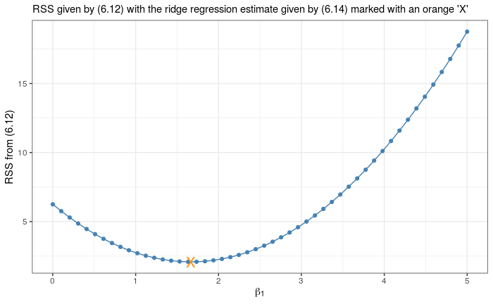

```r
y1 <- 2.5
lambda <- 0.5
b1 <- seq(0, 5, len = 50) # beta1
RSS <- (y1 - b1)^2 + lambda*(b1)^2 # (6.12)
b.R = y1/(1 + lambda) # (6.13)

ggplot(data.frame(b1, RSS)) +
  geom_point(aes(b1, RSS), color = "steelblue") +
  geom_line(aes(b1, RSS), color = "steelblue") +
  geom_point(data = data.frame(x = b.R, y = (y1 - b.R)^2 + lambda*(b.R)^2),
             aes(x, y),
             shape = 'X', color = "darkorange", size = 5) +
  labs(x = expression(beta[1]), y = "RSS from (6.12)",
       title = "RSS given by (6.12) with the ridge regression estimate given by (6.14) marked with an orange 'X'") +
  theme(plot.title = element_text(size = 11))
```

### (b)

In this part we are exploring (6.13) and (6.15):
$$\sum_{j=1}^{p} (y_j - \beta_j)^2 + \lambda \sum_{j=1}^{p} |\beta_{j}| \hspace{2cm} (6.13)$$
$$\hat{\beta}_j^L =
\begin{cases}
y_j - \lambda/2 & \text{if } y_j > \lambda/2; \\
y_j + \lambda/2 & \text{if }y_j < -\lambda/2; \\
0 & \text{if } |y_j| \le \lambda/2.
\end{cases}
\hspace{2cm} (6.15)$$

Let $y_1 = 2.5$ and $\lambda = 0.5$. Below is a plot of the RSS given by (6.13) as a function of $\beta_1$. Also marked on the plot with an orange ‘X’ is the lasso estimate given by (6.15). It can clearly be seen that this is the value that minimizes (6.13):

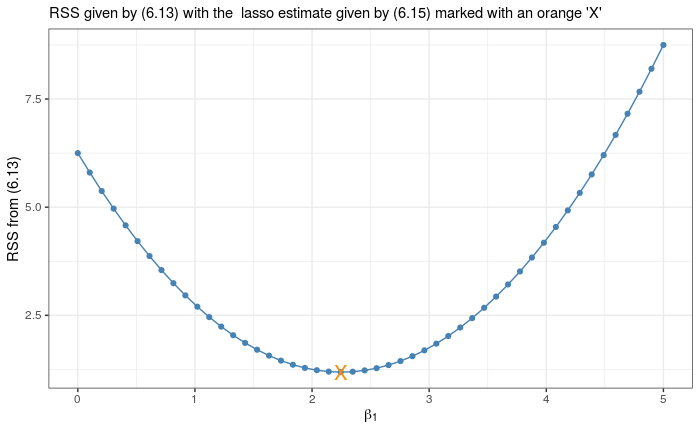

```r
y1 <- 2.5
lambda <- 0.5
b1 <- seq(0, 5, len = 50) # beta1
RSS <- (y1 - b1)^2 + lambda*abs(b1) # (6.13)
b.L <- y1 - lambda/2 # (6.15) y1 > lambda/2

ggplot(data.frame(b1, RSS)) +
  geom_point(aes(b1, RSS), color = "steelblue") +
  geom_line(aes(b1, RSS), color = "steelblue") +
  geom_point(data = data.frame(x = b.L, y = (y1 - b.L)^2 + lambda*abs(b.L)),
             aes(x, y),
             shape = 'X', color = "darkorange", size = 5) +
  labs(x = expression(beta[1]), y = "RSS from (6.13)",
       title = "RSS given by (6.13) with the  lasso estimate given by (6.15) marked with an orange 'X'") +
  theme(plot.title = element_text(size = 11))
```

[^1]: James G, Witten D, Hastie T, Tibshirani R (2013). *An Introduction to Statistical Learning: with Applications in R*. Springer, 1st edition.